# Import libraries

# Variable 7:- CNAME

```python
print(df['CNAME'].unique())
print(df['CNAME'].nunique())
```

```
['INDIA GARAGE SERVICE STATION' 'BENAKA ENTERPRISE' 'MJV SERVICE'
 'JCPL FUEL STATION' 'MJV SERVICES WHITEFILED BANGAL' 'LIBERTY AUTO'
 'PKP NAIR' 'P K PARAMESWARAN NAIR' 'NEW KAMPALA SERVICE STATION'
 'NOBLE MOTORS' 'NEW KAMPALA S. STATION' 'UNITED MOTORS INDIA PVT LTD.'
 'WORLIWAY SERVICE STATION A/C P' 'WORLIWAY SERVICE STATION-II'
 'SHUBAM PETROL DEPOT (ADHOC)' 'RAVI AUTO SERVICES' 'VADGAON PETROLEUM'
 'SANDIP PETROLEUM' 'BP COCO EXPRESS WAY' 'OM VEDANT PETROLEUM'
 'BP-BANDRA KURLA COMPLEX' 'GATEWAY AUTO SERVICE' 'DIPTI PETROLEUM'
 'FAMOUS AUTO SERVICE STATION' 'BHARUCHA AUTO SERVICE'
 'PATEL AUTOMOBILES_2' 'SAHYADRI SERVICE STATION' 'V.V.VARDE'
 'BOMBAY PETROLEUMS' 'AMAR AUTOMOBILES (A/C MAHESHWA'
 'VIKHROLI AUTOMOBILES' 'BP KANDIVALI' 'UNITED MOTORS'
 'DAYARAM SANTDAS & CO' 'DAYARAM SANTADAS &AMP CO' 'SHRADHA PETROL PUMP'
 'MANGALYAM PETROLEUM' 'ROHIT PETROLEUM SERVICE' 'ROSHANI SERVICES'
 'AURO PETROLEUM CENTRE' 'RADIANT PETROLEUM PROD.PVT.LTD'
 'KAUSAR AUTO SERVICE' 'JAIHIND HIGHWAY SERVICE STATIO' 'PARK GARAGE'
 'VARDAAN FUEL STATION' 'BORIVALI  PETROL SUPPLY CO' 'KENIA AUTOMOBILES'
 'SHETKARI SAHKARI SANGH LIMITED' 'UGANDA SERVICE STATION'
 'KAKA AUTOMOBILES' 'TAXIMENS SERVICES' 'SIDDHIVINAYAK FUEL CENTRE'
 'BP-BKC' 'GATEWAY  AUTO SERVICES' 'PETROLEUM & MINERALS PVT LTD A'
 'PETROLEUM &AMP MINERALS (T) (T' 'DESAI AUTO SERVICE'
 'VISHRAM SERVICE CENTRE' 'BAHRI AUTO SERVICE' 'BORIVALI PETROL SUPPLY'
 'ADARSH SERVICE STATION' 'NEW KAMPALA S. STATION ADHOC'
 'LAKHBIR AUTOMOBILES' 'PATEL AUTOMOBILESA/C GOREGAON' 'BOMBAY PETROLEUM'
 'NEW KAMPALA S STATION' 'NEW BOMBAY AUTO SUPPLY CO'
 'TAXIMENS SERVICES LTD. (A/C BA' 'TAXIMAN SERVICES LTD'
 'BAJRANG AUTO SERVICE' 'GURUNANAK AUTOMOBILES A/C ANDH'
 'GURUNANAK AUTOMOBILESA/C ANDHE' 'SINGH ROADLINES' 'BP CHURCHGATE'
 'EXPRESS PETROLEUM COLABA' 'LIBERTY  AUTOMOBILES' 'MOHANISH AUTO CENTRE'
 'GANESH AUTOMOBILES' 'J.K.& SONS' 'NOBLE MOTORS SERVICE'
 'GILL AUTO SERVICE' 'MANHAS AUTO SERVICE' 'TAJ AUTOMOBILES'
 'R.N.GUPTA BROTHERS & SONS' 'SETHI AUTOMOBILES' 'R.M. CHOUBE & SONS'
 'PRAKASH AUTOMOBILES A/C JVPD' 'PRAKASH AUTOMOBILES_2'
 'SHAHEED BAPURAO DHURGUDE AUTOW' 'SATGURU AUTOMOBILES (A/C WADAL'
 'SATGURU AUTOMOBILES' 'CHHEDA SERVICE STATION' 'DAULAT AUTOMOBILES'
 'MAHAVIR AUTO' 'SHETTY AUTO SERVICE' 'BRIGHT STAR SERVICES'
 'HIGHWAY AUTOMOBILES GHATKOPAR' 'LAD BANDHU SERVICE' 'LAXMI TRADERS'
 'SHREE SIDDHIVINAYAK_EWAY' 'GOREGAON PETROL SUPPLY CO'
 'CHARKOP PETROLEUM' 'SUPRABHAT TRANSPORT COMP' 'EXPRESS SERVICES QR'
 'UNIVERSAL SERVICE CENTRE' 'SM FILLING CENTRE'
```

[output cut: 23 more lines]

```
 'OM SAMARTH PETROLEUM' 'KRISHNAI PETROCHEMICALS' 'V V VARDE'
 'SIDHARTH AGENCIES' 'ANAND HIGHWAY SERVICES' 'H.L.DHATRAK & SONS'
 'NATIONAL PETROL CO ( A/C DADAR' 'BASSEIN PETROL SUPPLY CO'
 'ANANT FILLING STATION' 'SAKSHAM MOTORS' 'USHA HIGHWAY FILLING STATION'
 'AKASHI FILLING STATION' 'SURENDRA & CO' 'J.SINGH BROTHERS  (A/C GP RD)'
 'TAXIMENS SERVICES LTD (A/C BAN' 'SWAGAT PETROLEUM'
 'ABHISHEK SRVICE CENTRE' 'SARDAR AUTOMOBILES' 'SHIRDHON SERVICE STATION'
 'SHREE LAXMINARAYAN PETROLINKS' 'BP KALAMBOLI 2' 'BP- SANPADA'
 'SHIV SHAKTI PETROLEUM' 'VIJAYBHARAT PETROLEUM' 'DASHMESH AUTOMOBILES'
 'EXPRESS PETRO SERVICES DAPODI' 'BP KELEWADE' 'HUTATMA RAJGURU SERVICES'
 'SHRI NAGESHWAR PETROLEUM' 'K.B. LAHOTI  SANGAMNER'
 'DAYARAM SANTADAS &AMP; CO' 'BP-VELACHERY' 'KOHINOOR'
 'MADRAS CITY LORRY OWNERS ASSOC' 'CAMAC' 'SHYAMA TRADING CO.'
 'MILAP SERVICE STATION']
206
```

# Find the total count of each data_item using value_count()

```python
print(df['CNAME'].value_counts())
```

```
WORLIWAY SERVICE STATION A/C P    426
RAVI AUTO SERVICES                108
GATEWAY  AUTO SERVICES             84
NOBLE MOTORS                       68
ADARSH SERVICE STATION             68
                                 ...
AKASHI FILLING STATION              1
SETHI AUTOMOBILES                   1
C.R.CONTRACTOR                      1
KRISHNAI PETROCHEMICALS             1
KOHINOOR                            1
Name: CNAME, Length: 206, dtype: int64
```

# Plotting of graph using bar graph:-As we know that bar graph is generally used for comparision of two category in a particular column but if we have continuous variable then we use to take the top 5 or 10 data_items because as we know that we if we plot all the data_item then in graph all the data_item will appear close to each other due to which analysis of data is not done properly and bars will overlap with each other and due to which we will not able to analyze the total count of any data_item and hence anlaysis will not be done clearly with bar graph.

[output not shown]

[figure not shown]

```python
x=["WORLIWAY","RAVIAU","GATEWAYAU","NOBLE","ADARSHSERV","AKASHI"]
Y=[108,84,68,68,1]
plt.xlabel('CNAME')
plt.ylabel('Total_count')
plt.bar(x,y,width =0.1,color =['blue','yellow'])
```

# Variable 8:-DELCITY

```python
print(df['DELCITY'].unique())
print(df['DELCITY'].nunique())
```

```
['Bangalore' 'Kanchipuram' 'BANGALORE' 'MUMBAI' 'Thiruvananthapuram'
 'TRIVANDRUM' 'Mumbai' 'Pune' 'KOLHAPUR' 'BARAMATI' 'PUNE' 'Belgaum'
 'Nashik' 'Raigarh' 'THANE' 'VASAI' 'Burhanpur' 'Thane' 'Jalgaon'
 'RATNAGIRI' 'PUNAWALE - TAL. MULSHI' 'Satara' 'Ahmednagar' 'NASHIK'
 'Ahmedabad' 'Vellore' 'Surat' 'Udaipur' 'Vadodara' 'Rajkot' 'KUTCH'
 'Valsad' 'Madurai' 'North Goa' 'South Goa' 'South Delhi' 'Faridabad'
 'Gurgaon' 'Sirohi' 'SINDHUDURG' 'Chennai' 'Kolkata']
42
```

# Find the total count of each data_item using value_count()

```python
print(df['DELCITY'].value_counts())
```

```
Mumbai                    1528
MUMBAI                     114
Nashik                      83
Thane                       75
Pune                        45
Bangalore                   24
Thiruvananthapuram          12
Kolkata                      7
Chennai                      6
THANE                        6
Raigarh                      5
Satara                       5
Belgaum                      3
KOLHAPUR                     3
NASHIK                       3
South Goa                    2
BANGALORE                    2
Udaipur                      2
Ahmednagar                   2
PUNE                         2
Ahmedabad                    2
RATNAGIRI                    2
Surat                        2
PUNAWALE - TAL. MULSHI       1
Sirohi                       1
VASAI                        1
Rajkot                       1
North Goa                    1
Vellore                      1
TRIVANDRUM                   1
Vadodara                     1
SINDHUDURG                   1
BARAMATI                     1
KUTCH                        1
Gurgaon                      1
Kanchipuram                  1
Faridabad                    1
Madurai                      1
Valsad                       1
South Delhi                  1
Burhanpur                    1
Jalgaon                      1
Name: DELCITY, dtype: int64
```

# Plotting of graph using bar graph:-As we know that bar graph is generally used for comparision of two category in a particular column but if we have pure string then also we use to take the top 5 or 10 data_items because as we know that we if we plot all the data_item then in graph all the data_item will appear close to each other due to which analysis of data is not done properly and bars will overlap with each other and due to which we will not able to analyze the total count of any data_item and hence anlaysis will not be done clearly with bar graph.

```
<BarContainer object of 7 artists>
```

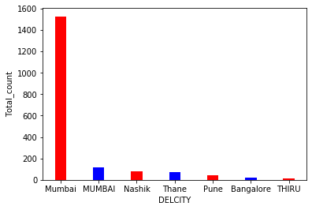

```python
x=["Mumbai", "MUMBAI" , "Nashik" , "Thane" , "Pune" , "Bangalore" , "THIRU"]
y=[1528,114,83,75,45,24,12]
plt.xlabel('DELCITY')
plt.ylabel('Total_count')
plt.bar(x,y,width =0.3,color =['red','blue'])
```

# Variable 9:-AU_MOTOR

```python
print(df['AU_MOTOR'].unique())
print(df['AU_MOTOR'].nunique())
```

```
[31.   54.03 60.06 ... 58.04 64.24 68.66]
1387
```

# Find the total count of each data_item using value_count()

```python
print(df['AU_MOTOR'].value_counts())
```

```
30.00    42
40.00    21
50.00    18
45.00    16
35.00    14
         ..
61.34     1
36.50     1
45.67     1
43.39     1
25.03     1
Name: AU_MOTOR, Length: 1387, dtype: int64
```

# Plotting of graph using bar graph:-As we know that bar graph is generally used for comparision of two category in a particular column but if we have continuous variable then we use to take the top 5 or 10 data_items because as we know that we if we plot all the data_item then in graph all the data_item will appear close to each other due to which analysis of data is not done properly and bars will overlap with each other and due to which we will not able to analyze the total count of any data_item and hence anlaysis will not be done clearly with bar graph.

```
<BarContainer object of 6 artists>
```

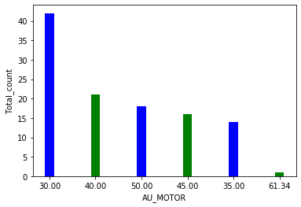

```python
x=["30.00","40.00","50.00","45.00","35.00","61.34"]
y=[42,21,18,16,14,1]
plt.xlabel('AU_MOTOR')
plt.ylabel('Total_count')
plt.bar(x,y,width =0.2,color =['blue','green'])
```

# Variable 10:-ODOMETR

```python
print(df['ODOMETR'].unique())
print(df['ODOMETR'].nunique())
```

```
[17937 18590 19913 ... 60808 63928   898]
1749
```

# Find the total count of each data_item using value_count()

```python
print(df['ODOMETR'].value_counts())
```

```
0        51
1        23
12        9
11        6
1234      5
         ..
27674     1
70339     1
37575     1
11777     1
75775     1
Name: ODOMETR, Length: 1749, dtype: int64
```

# Plotting of graph using bar graph:-As we know that bar graph is generally used for comparision of two category in a particular column but if we have continuous variable then we use to take the top 5 or 10 data_items because as we know that we if we plot all the data_item then in graph all the data_item will appear close to each other due to which analysis of data is not done properly and bars will overlap with each other and due to which we will not able to analyze the total count of any data_item and hence anlaysis will not be done clearly with bar graph.

```
<BarContainer object of 6 artists>
```

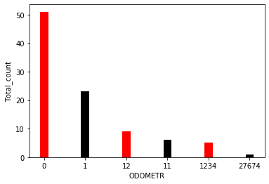

```python
x=["0","1","12","11","1234","27674"]
y=[51,23,9,6,5,1]
plt.xlabel('ODOMETR')
plt.ylabel('Total_count')
plt.bar(x,y,width =0.2,color =['red','black'])
```